# BMIN503/EPID600 Project Template

Katie Tsukahara

### Overview

> OVERVIEW:  
> Childhood interstitial lung disease (chILD) is a heterogeneous group of rare childhood lung diseases affecting the interstitial region of the lung, leading to abnormal gas exchange and a range of morbidity and mortality. Research and development of therapies is challenging due to the low prevalence and heterogeneity of disease, thus the CHILD Research Network and Registry was established to collect data from multiple centers across the United States. Our goal is to compare patient demographics across subsets of chILD subjects by diagnosis, and to examine the diagnostic and clinical factors that contribute to diagnosis.

### Introduction

> INTRODUCTION:  
> Childhood interstitial lung disease (chILD) encompasses a variety of lung diseases that manifest via changes to the pulmonary interstitium. The pulmonary interstitium is, simply put, the lung tissue between the airspace and the pulmonary blood vessels, and excludes other lung structures such as the airways. These diseases are grouped together owing to similarities in the area of the lung affected and in clinical presentation. While both children and adults can develop interstitial lung disease (ILD), many causes of chILD are seen only in the pediatric age group. These diseases can be genetic in origin, or associated with abnormal lung development, immunologic dysfunction, rheumatologic disease, or infectious history. Some cases do not have a clear etiology. Certain diagnoses confer a poor prognosis of early lung transplant or mortality. Other diagnoses confer a more positive prognosis, including clinical improvement and resolution of disease over early childhood.  
> To study this group of diseases, the Children’s Interstitial and Diffuse Lung Disease Research Network (ChILDRN) established a national registry in 2016, with participation by 13 sites across the United States. The original registry contains 436 subjects, enrolled from 2016 to 2020, with data on demographics, medical history, diagnostics, management and outcomes. With this project, we aim to examine differences in patient demographics, including age of onset and severity of presentation, among the more common chILD diagnoses. We also aim to examine the diagnostic and clinical factors that contribute to diagnosis, if possible examining the role that different diagnostic tests play in diagnosis and whether invasive testing can be avoided in these patients that are at higher risk for procedures due to their underlying pulmonary disease. The database and this subsequent project use the skills and expertise of clinicians across many fields (Pulmonology, Radiology, Pathology, Rheumatology, and others), clinical researchers, basic science researchers, and biomedical informaticians to collect, manage, and interpret data on this complex group of patients.

### Results

```r
# enrollment statistics
summary(child$age_studyentry)
```

```
##      Min.   1st Qu.    Median      Mean   3rd Qu.      Max.      NA's
##   0.09855  35.68495  93.70825 100.24740 156.48817 260.31537         2
```

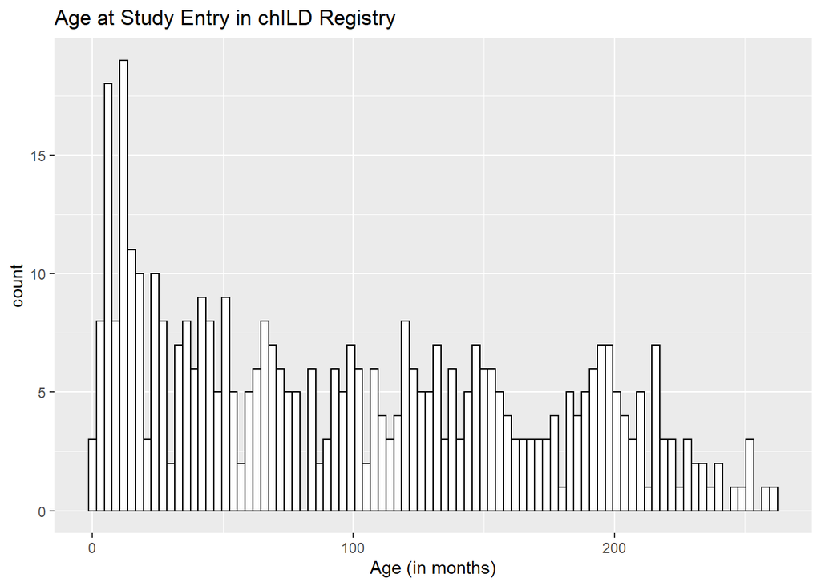

```r
ggplot(data = child, aes(x = age_studyentry)) +
  geom_histogram(color = "black", fill = "white", binwidth=3) +
  labs(x = "Age (in months)", title = "Age at Study Entry in chILD Registry")
```

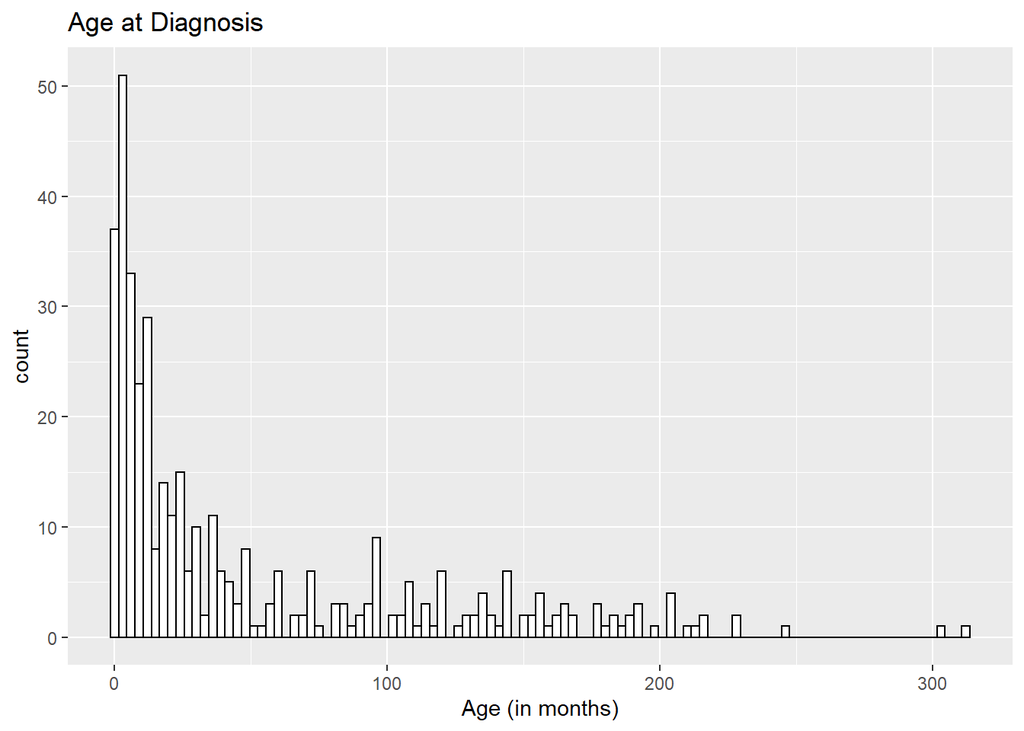

```r
ggplot(data = child, aes(x = age_diagnosis)) +
  geom_histogram(color = "black", fill = "white", binwidth=3) +
  labs(x = "Age (in months)", title = "Age at Diagnosis")
```

```r
#ggplot(child, aes(age_diagnosis, age_studyentry)) +
 # geom_jitter() +
  #labs(x = "Age at Diagnosis (in months)", y = "Age at Study Entry (in months)", title = "chILD Regsitry: Timing of Diagnosis vs Study Entry")
```

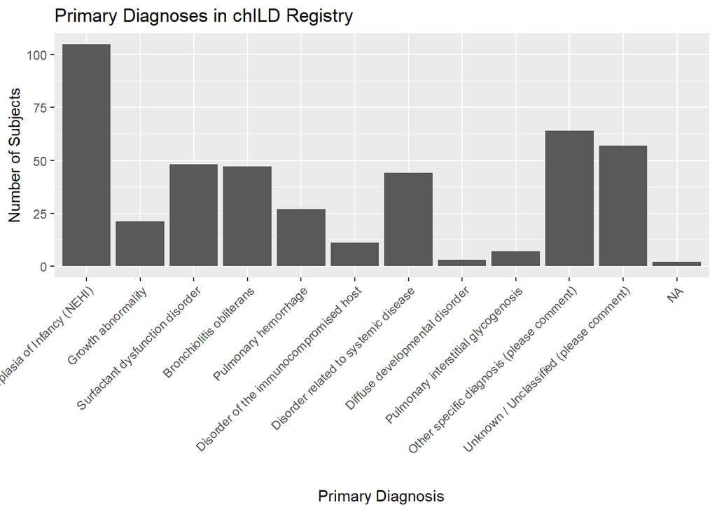

```r
# gender across diagnosis


ggplot(data = child, aes(x = diagnosis.factor)) +
  geom_bar() +
  theme(axis.text.x = element_text(angle = 45, hjust = 1)) +
  labs(x = "Primary Diagnosis", y = "Number of Subjects", title = "Primary Diagnoses in chILD Registry")
```

```r
p1chi <- chisq.test(table(child$diagnosis.factor, child$patient_gender.factor))
p1chi
```

```
##
##  Pearson's Chi-squared test
##
## data:  table(child$diagnosis.factor, child$patient_gender.factor)
## X-squared = 26.185, df = 10, p-value = 0.003499
```

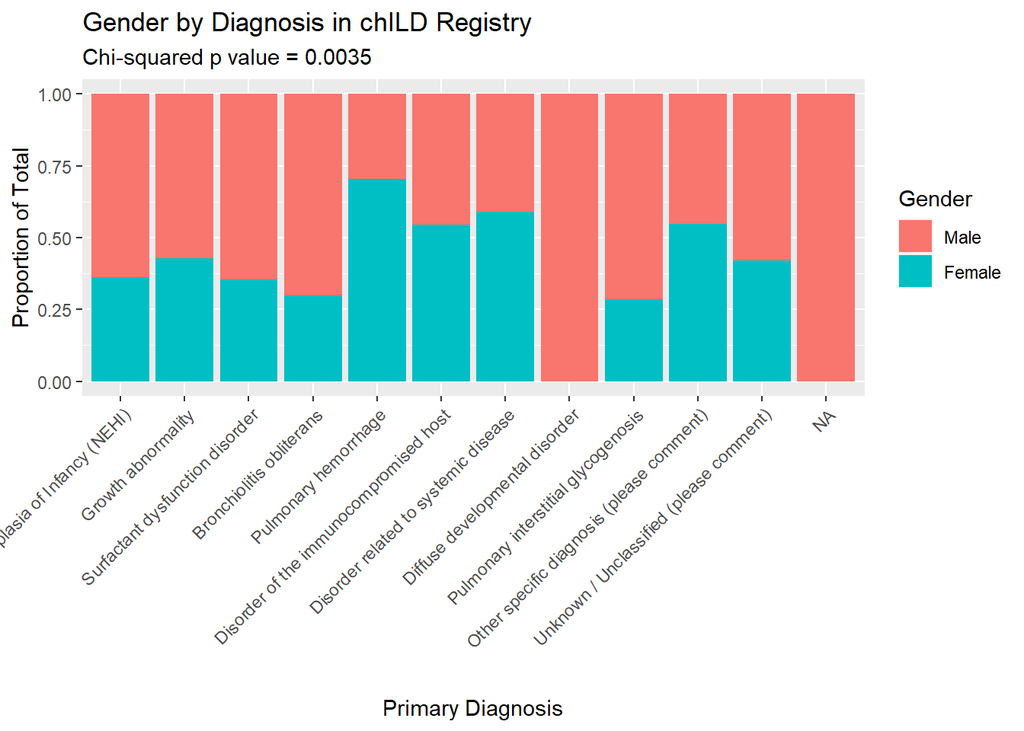

```r
ggplot(data = child, aes(x = diagnosis.factor, fill = patient_gender.factor)) +
  geom_bar(position = "fill") +
  theme(axis.text.x = element_text(angle = 45, hjust = 1)) +
  labs(x = "Primary Diagnosis", y = "Proportion of Total", title = "Gender by Diagnosis in chILD Registry", fill = "Gender",subtitle = paste("Chi-squared p value =", format(p1chi$p.value, digits = 3)))
```

```r
# age across diagnosis

summary(data$age_diagnosis)
```

```
##    Min. 1st Qu.  Median    Mean 3rd Qu.    Max.    NA's
##    0.00    5.00   20.00   49.94   81.50  312.00      41
```

```r
mean(data$age_diagnosis, na.rm = TRUE)
```

```
## [1] 49.94071
```

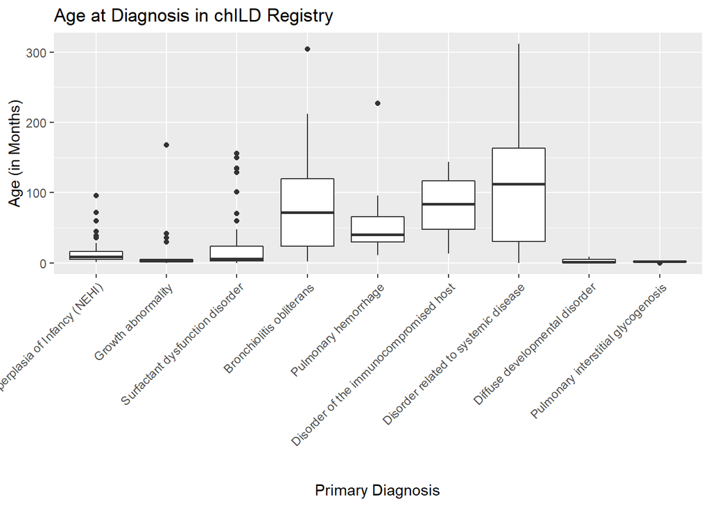

```r
ggplot(data = filter(child, child$diagnosis < 10), aes(x = diagnosis.factor, y = age_diagnosis)) +
  geom_boxplot() +
  theme(axis.text.x = element_text(angle = 45, hjust = 1)) +
  labs(x = "Primary Diagnosis", y = "Age (in Months)", title = "Age at Diagnosis in chILD Registry")
```

```r
# looking at age at diagnosis and diagnostic modality

child.mod <- select(child, child_registry_id:diagnosis, fibrosis.factor:diagnosis.factor)
child.mod <- child.mod %>%
  mutate(modality = ifelse(child.mod$child_dia2___1 == 1 & child.mod$child_dia2___2 == 0 & child.mod$child_dia2___3 == 0 & child.mod$child_dia2___4 == 0, "CT only", NA)) %>%
  mutate(modality = ifelse(child.mod$child_dia2___2 == 1 & child.mod$child_dia2___1 == 0 & child.mod$child_dia2___3 == 0 & child.mod$child_dia2___4 == 0, "Biopsy only", modality)) %>%
  mutate(modality = ifelse(child.mod$child_dia2___3 == 1 & child.mod$child_dia2___1 == 0 & child.mod$child_dia2___2 == 0 & child.mod$child_dia2___4 == 0, "Genetic only", modality)) %>%
  mutate(modality = ifelse(child.mod$child_dia2___2 == 0 & child.mod$child_dia2___1 == 0 & child.mod$child_dia2___3 == 0 & child.mod$child_dia2___4 == 0, "No Diagnositc Modality Listed", modality)) %>%
  mutate(modality = ifelse(child.mod$child_dia2___4 == 1 & child.mod$child_dia2___1 == 0 & child.mod$child_dia2___2 == 0 & child.mod$child_dia2___3 == 0, "Other", modality)) %>%
  mutate(modality = ifelse(is.na(modality) == "TRUE", "Multiple", modality)) %>%
  mutate(modality.factor = as.factor(modality))


table(child.mod$modality)
```

```
##
##                   Biopsy only                       CT only                  Genetic only                      Multiple No Diagnositc Modality Listed                         Other
##                            25                           123                            29                           237                             4                            18
```

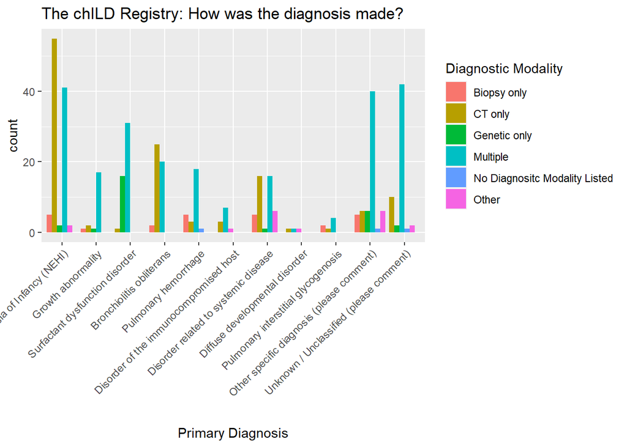

```r
ggplot(data = filter(child.mod, !is.na(diagnosis)), aes(x = diagnosis.factor, fill = modality.factor)) +
  geom_bar(position = position_dodge(preserve = "single")) +
  theme(axis.text.x = element_text(angle = 45, hjust = 1)) +
  labs(x = "Primary Diagnosis", fill = "Diagnostic Modality", title = "The chILD Registry: How was the diagnosis made?")
```

```r
child.surf <- filter(child, diagnosis.factor == "Surfactant dysfunction disorder")
print(paste0("In the chILD Registry, there are ", nrow(child.surf), " entries with a primary diagnosis of surfactant dysfunction disorder"))
```

```
## [1] "In the chILD Registry, there are 48 entries with a primary diagnosis of surfactant dysfunction disorder"
```

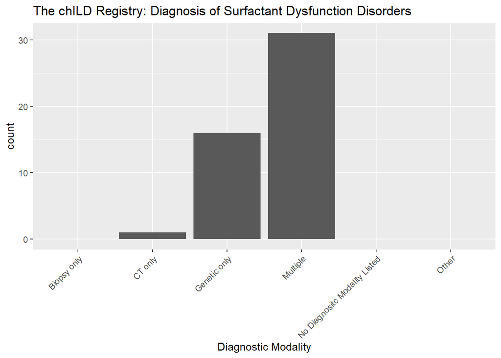

```r
ggplot(data = filter(child.mod, diagnosis.factor == "Surfactant dysfunction disorder"), aes(x = modality.factor)) +
  geom_bar() +
  scale_x_discrete(drop=FALSE) +
  theme(axis.text.x = element_text(angle = 45, hjust = 1)) +
  labs(x = "Diagnostic Modality", title = "The chILD Registry: Diagnosis of Surfactant Dysfunction Disorders")
```

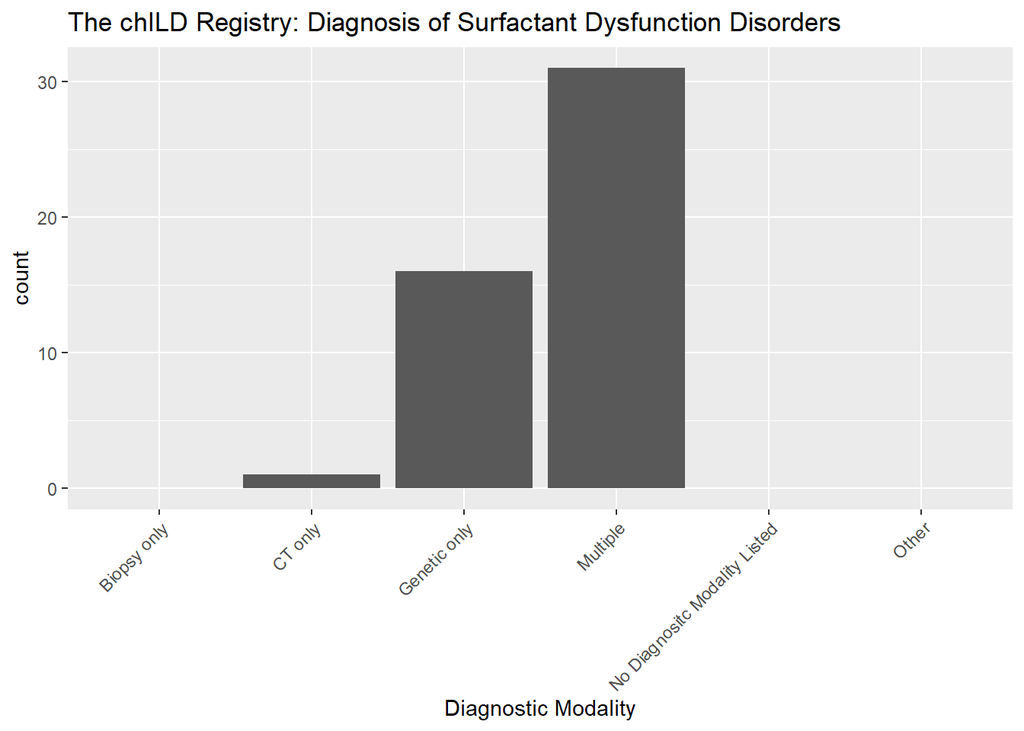

```r
ggplot(data = filter(child.mod, diagnosis.factor == "Surfactant dysfunction disorder"), aes(x = modality.factor)) +
  geom_bar() +
  scale_x_discrete(drop=FALSE) +
  theme(axis.text.x = element_text(angle = 45, hjust = 1)) +
  labs(x = "Diagnostic Modality", title = "The chILD Registry: Diagnosis of Surfactant Dysfunction Disorders")
```

```r
# colSums(select(child.surf, child_dia2___1:child_dia2___4), na.rm = TRUE)
# head(filter(child.surf, child_dia2___4 == 1) %>% select(child_registry_id:child_dia2___4)) - shows only 1 entry

library(VennDiagram)
library(magick)

venn.ct <- child.surf %>% filter(child_dia2___4 == 0) %>% select(child_registry_id, child_dia2___1) %>% filter(child_dia2___1 == 1) %>% mutate(venn.modality = "CT") %>% select(child_registry_id, venn.modality)
venn.bx <- child.surf %>% filter(child_dia2___4 == 0) %>% select(child_registry_id, child_dia2___2) %>% filter(child_dia2___2 == 1) %>% mutate(venn.modality = "Biopsy") %>% select(child_registry_id, venn.modality)
venn.gen <- child.surf %>% filter(child_dia2___4 == 0) %>% select(child_registry_id, child_dia2___3) %>% filter(child_dia2___3 == 1) %>% mutate(venn.modality = "Genetic Testing") %>% select(child_registry_id, venn.modality)
venn <- rbind(venn.ct, venn.bx, venn.gen)

#child.surf %>% filter(child_dia2___4 == 0 & child_dia2___1 == 0 & child_dia2___3 == 0) %>% head()
#child.surf %>% filter(child_dia2___4 == 0 & child_dia2___2 == 0 & child_dia2___3 == 0) %>% head()
#child.surf %>% filter(child_dia2___4 == 0 & child_dia2___1 == 0 & child_dia2___3 == 0) %>% head()

venn.diagram(
  x = list(
    venn %>% filter(venn.modality == "CT") %>% select(child_registry_id) %>% unlist() ,
    venn %>% filter(venn.modality == "Biopsy")  %>% select(child_registry_id) %>% unlist() ,
    venn %>% filter(venn.modality == "Genetic Testing") %>% select(child_registry_id) %>% unlist()
    ),
  category.names = c("Chest Computed Tomography (CT)" , "Lung Biopsy" , "Genetic Testing"),
  filename = 'venn.png',
  output = TRUE ,
          imagetype="png" ,
          height = 480 ,
          width = 480 ,
          resolution = 300,
          compression = "lzw",
          lwd = 1,
          col=c("#440154ff", '#21908dff', '#fde725ff'),
          fill = c(alpha("#440154ff",0.3), alpha('#21908dff',0.3), alpha('#fde725ff',0.3)),
          cex = 0.5,
          fontfamily = "sans",
          cat.cex = 0.3,
          cat.default.pos = "outer",
          cat.pos = c(-27, 27, 120),
          cat.dist = c(0.085, -0.055, 0.055),
          cat.fontfamily = "sans",
          cat.col = c("#440154ff", '#21908dff', '#fde725ff'),
          rotation = 1
        )
```

```
## [1] 1
```

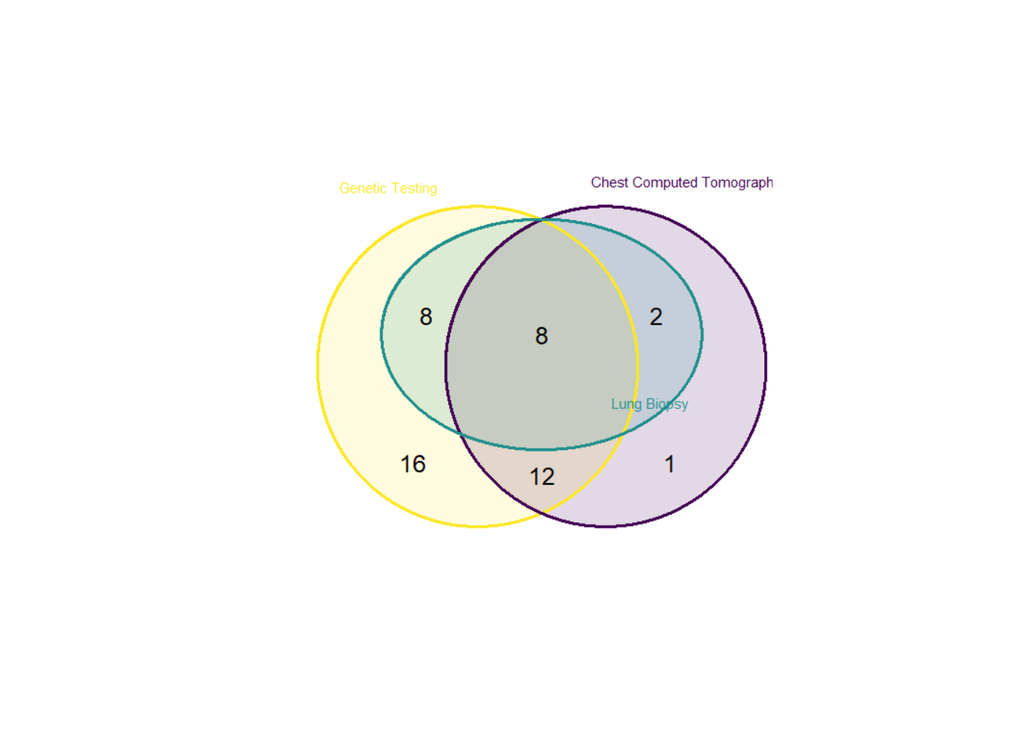

```r
img <- magick::image_read('C:/Users/tsukaharak/Documents/R files/BMIN503_Final_Project/venn.png')
plot(img) # or print(img)
```

### Acknowledgements

We would like to thank the Children’s Interstitial and Diffuse Lung Disease Research Network (chILDRN) and Dr. Lisa Young for the opportunity to work on this project.